# Model sanity check

Shoshana Rapley

2025-02-10

Metadata gets appended a bunch, here it is:

```r
# Metadata - translocation information
metadata  <- read.csv("data/metadata.csv") %>%
  clean_names() %>%
  rename(id = identity,
         mortality = mortality_or_capture) %>%
  mutate(start_date = as_date(dmy(start_date)),
         end_date = as_date(dmy(end_date)),
         mortality = as_date(dmy(mortality)))
```

# Statistical analysis: reinforcers

We hypothesised members of the mixed resident-reinforcer social group would proceed more quickly through the PRBM phases than those in the reinforcer only group. I also want to compare both reinforcer groups to the residents to see if one is more similar than the other.

Dates are from the last reinforcer released to the first reinforcer translocated to the secondary site.

```r
# social group membership
club <- c("Rowan", "Rory", "Fauna", "Zeus", "Rocky", "Sofi", "Loki", "Avery", "Maeve")

# define reinforcer date period
rein_dates <- seq.Date(from = as_date("2023-06-11"), to = as_date("2023-08-05"), by = "day")
```

### m1: Distance moved

Does daily distance moved differ between the social groups?

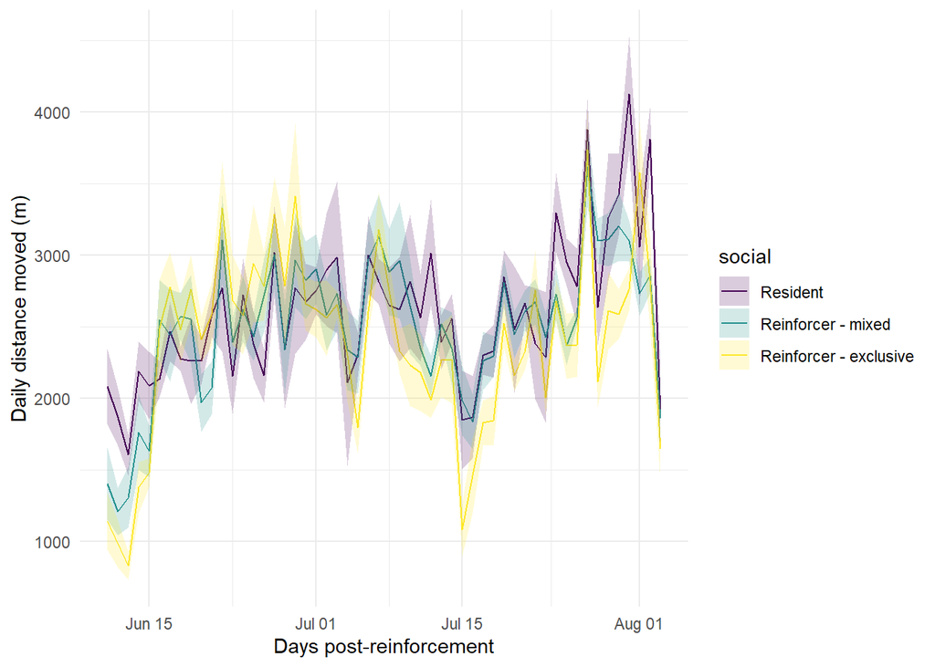

```r
# read in data and filter to reinforcement period
datam1 <- read.csv("results/daily_distance_moved.csv") %>%
  # add metadata
  left_join(dplyr::select(metadata, c("id", "cohort"))) %>%
  # format dates as dates
  mutate(date = as_date(date_bird)) %>%
  # limit to reinforcement period
  filter(date %in% rein_dates) %>%
  # add a time elapsed post-release variable
  mutate(elapsed = as.numeric(date - as_date("2023-06-10"))) %>%
  # add column for membership to social group
  mutate(social = ifelse(id %in% club, "Reinforcer - exclusive", ifelse(cohort == "Resident", "Resident", "Reinforcer - mixed"))) %>%
  # convert group to factor and set resident as the intercept
  mutate(social = factor(social, levels = c("Resident", "Reinforcer - mixed", "Reinforcer - exclusive"))) %>%
  # add quadratic term for time
  mutate(elapsed2 = elapsed^2)

# create social group means
sum1 <- datam1 %>%
  group_by(date, social) %>%
  summarise(dist = mean(daily_dist),
            upper = dist + std.error(daily_dist),
            lower = dist - std.error(daily_dist)) %>%
  arrange(date)

# plot daily distance over time as social group means
ggplot(sum1, aes(date, dist, ymin = lower, ymax = upper)) +
  geom_path(aes(colour = social)) +
  geom_ribbon(aes(fill = social), alpha = 0.2) +
  xlab("Days post-reinforcement") +
  ylab("Daily distance moved (m)") +
  theme_minimal() +
  scale_fill_viridis_d()+
  scale_colour_viridis_d()
```

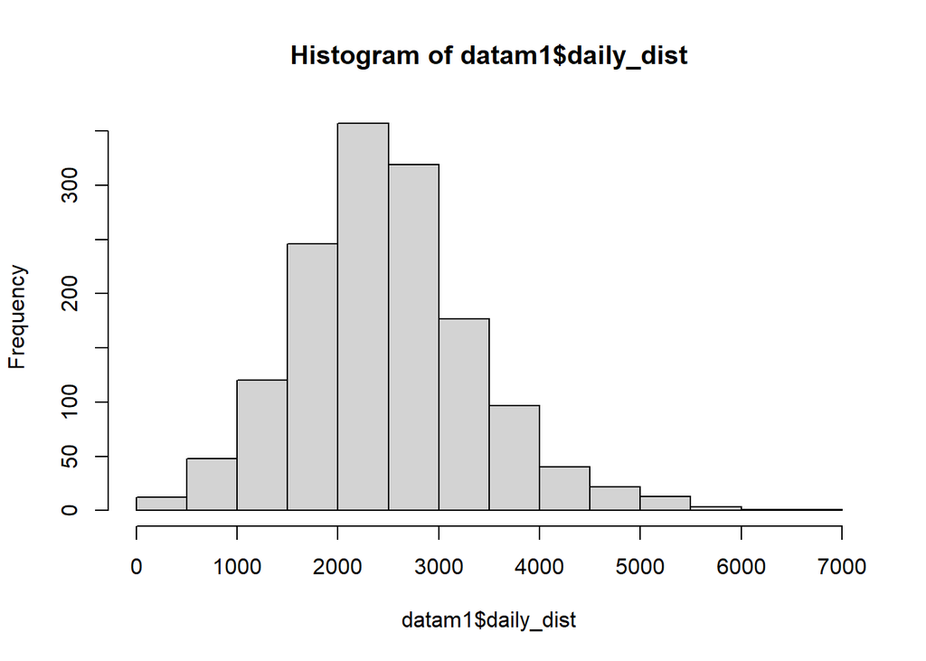

```r
# distribution of movement data
hist(datam1$daily_dist)
```

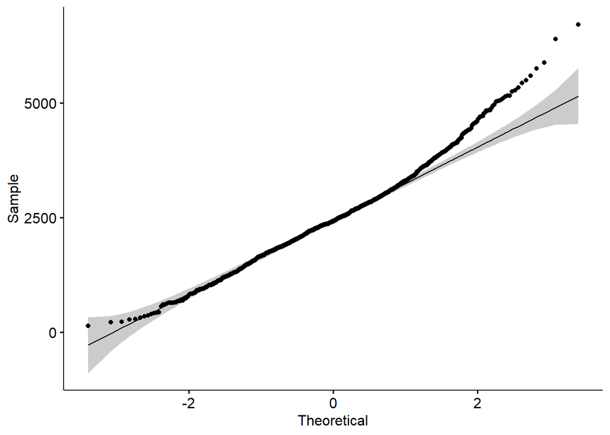

```r
ggqqplot(datam1$daily_dist)
```

```r
# test difference between the groups with interaction of time as a quadratic
m1 <- glmmTMB(daily_dist ~ social * (scale(elapsed) + scale(elapsed2))+ (1|id),
              data = datam1,
              na.action = "na.fail")

# model selection
dm1 <- dredge(m1)

# print best model on AICc
best1 <- get.models(dm1, delta==0)[[1]]
summary(best1)
```

```
##  Family: gaussian  ( identity )
## Formula:
## daily_dist ~ scale(elapsed) + scale(elapsed2) + social + (1 |
##     id) + scale(elapsed):social + scale(elapsed2):social
## Data: datam1
##
##      AIC      BIC   logLik deviance df.resid
##  23708.5  23766.6 -11843.3  23686.5     1445
##
## Random effects:
##
## Conditional model:
##  Groups   Name        Variance Std.Dev.
##  id       (Intercept) 100600   317.2
##  Residual             652340   807.7
## Number of obs: 1456, groups:  id, 28
##
## Dispersion estimate for gaussian family (sigma^2): 6.52e+05
##
## Conditional model:
##                                              Estimate Std. Error z value
## (Intercept)                                   2600.46     120.31  21.614
## scale(elapsed)                                 267.53     165.92   1.612
## scale(elapsed2)                                 11.06     165.72   0.067
## socialReinforcer - mixed                       -87.55     157.37  -0.556
## socialReinforcer - exclusive                  -218.57     164.30  -1.330
## scale(elapsed):socialReinforcer - mixed        504.66     214.76   2.350
## scale(elapsed):socialReinforcer - exclusive    357.74     223.16   1.603
## scale(elapsed2):socialReinforcer - mixed      -563.13     214.83  -2.621
## scale(elapsed2):socialReinforcer - exclusive  -534.58     222.50  -2.403
##                                              Pr(>|z|)
## (Intercept)                                   < 2e-16 ***
## scale(elapsed)                                0.10686
## scale(elapsed2)                               0.94680
## socialReinforcer - mixed                      0.57800
## socialReinforcer - exclusive                  0.18343
## scale(elapsed):socialReinforcer - mixed       0.01878 *
## scale(elapsed):socialReinforcer - exclusive   0.10892
## scale(elapsed2):socialReinforcer - mixed      0.00876 **
## scale(elapsed2):socialReinforcer - exclusive  0.01628 *
## ---
## Signif. codes:  0 '***' 0.001 '**' 0.01 '*' 0.05 '.' 0.1 ' ' 1
```

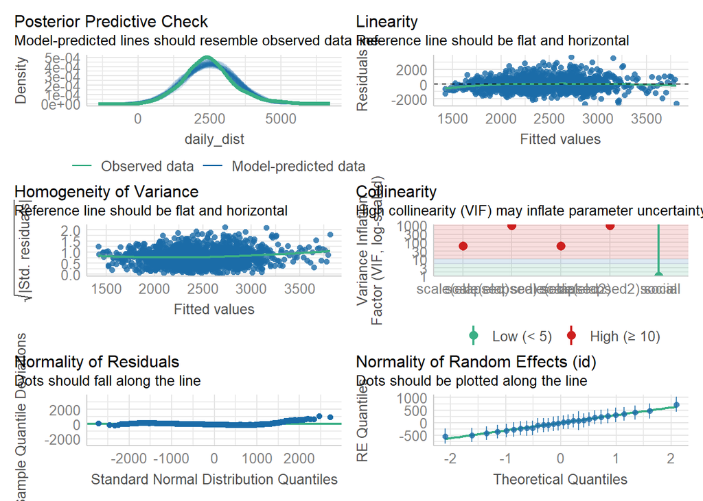

```r
# check model
check_model(best1)
```

```r
# post-hoc comparison of slopes
emtrends(best1, pairwise ~ social, var = "elapsed")
```

```
## $emtrends
##  social                 elapsed.trend    SE   df lower.CL upper.CL
##  Resident                        17.2 10.60 1445    -3.72     38.0
##  Reinforcer - mixed              49.5  8.75 1445    32.37     66.7
##  Reinforcer - exclusive          40.1  9.57 1445    21.33     58.9
##
## Confidence level used: 0.95
##
## $contrasts
##  contrast                                        estimate   SE   df t.ratio
##  Resident - (Reinforcer - mixed)                   -32.37 13.8 1445  -2.350
##  Resident - (Reinforcer - exclusive)               -22.94 14.3 1445  -1.603
##  (Reinforcer - mixed) - (Reinforcer - exclusive)     9.42 13.0 1445   0.727
##  p.value
##   0.0495
##   0.2446
##   0.7477
##
## P value adjustment: tukey method for comparing a family of 3 estimates
```

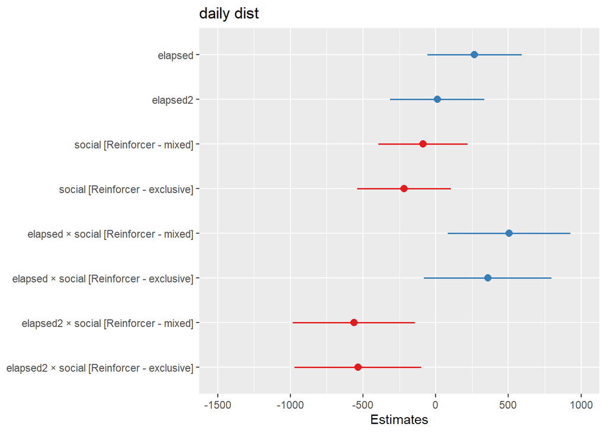

```r
# plot effects
plot_model(best1)
```

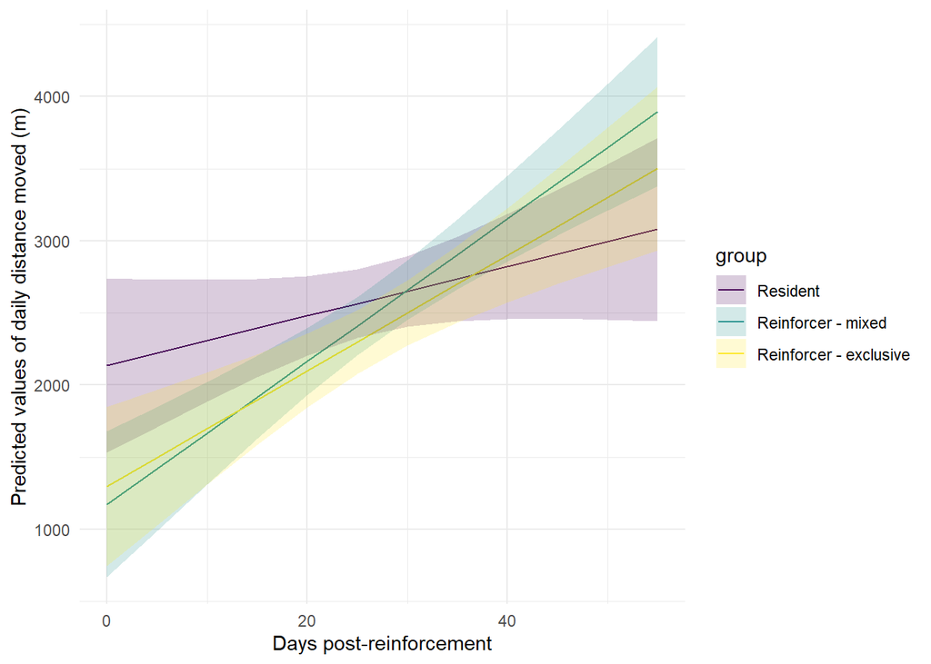

```r
# marginal effects
pred1 <- predict_response(best1, terms = c("elapsed", "social"))

# plot predictions
ggplot(pred1, aes(x, predicted, fill = group, ymin = conf.low, ymax = conf.high)) +
  geom_line(aes(colour = group))+
  geom_ribbon(alpha = 0.2)+
  xlab("Days post-reinforcement") +
  ylab("Predicted values of daily distance moved (m)") +
  theme_minimal()+
  scale_fill_viridis_d()+
  scale_colour_viridis_d()
```

**Results:** The best fitting model included social group and time (linear and quadratic), the interaction between these, and individual as a random effect.

Residents had relatively stable movement patterns over time (slight increase but not significant, estimate = 267.53m, se = 165.92, p = 0.10686). Whereas both reinforcer groups display a quadratic trajectory, initially increasing daily distance more rapidly, reaching a peak and then declining (significant negative trend for the quadratic terms). Their movement trajectories may eventually converge with those of residents.

**Interpretation:** Both sets of reinforcers increased their movement relative to residents (but significant only to the mixed group) suggesting that the need to move is common to translocated individuals regardless of social context. The reinforcers of both groups faced a common set of pressures: they must explore a novel environment to locate resources, assess habitat quality, and establish new social or territorial relationships.

### m2: Roost establishment

Does roost establishment differ between the social groups?

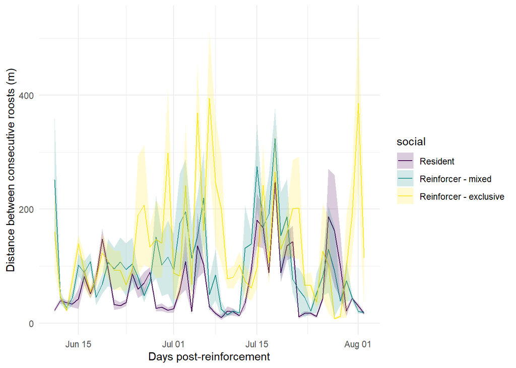

```r
# read in data and filter to reinforcement period
datam2 <- read.csv("results/daily_distance_between_roosts.csv") %>%
  # add metadata
  left_join(dplyr::select(metadata, c("id", "cohort"))) %>%
  # format dates as dates
  mutate(date = as_date(date)) %>%
  # limit to reinforcement period
  filter(date %in% rein_dates) %>%
  # add a time elapsed post-release variable
  mutate(elapsed = as.numeric(date - as_date("2023-06-10"))) %>%
  # add column for membership to social group
  mutate(social = ifelse(id %in% club, "Reinforcer - exclusive", ifelse(cohort == "Resident", "Resident", "Reinforcer - mixed"))) %>%
  # convert group to factor and set resident as the intercept
  mutate(social = factor(social, levels = c("Resident", "Reinforcer - mixed", "Reinforcer - exclusive"))) %>%
  # add quadratic term for time
  mutate(elapsed2 = elapsed^2)

# create social group means
sum2 <- datam2 %>%
  group_by(date, social) %>%
  summarise(dist = mean(distance_previous),
            upper = dist + std.error(distance_previous),
            lower = dist - std.error(distance_previous)) %>%
  arrange(date)

# plot roost displacement over time as social group means
ggplot(sum2, aes(date, dist, ymin = lower, ymax = upper)) +
  geom_path(aes(colour = social)) +
  geom_ribbon(aes(fill = social), alpha = 0.2) +
  xlab("Days post-reinforcement") +
  ylab("Distance between consecutive roosts (m)") +
  theme_minimal() +
  scale_fill_viridis_d()+
  scale_colour_viridis_d()
```

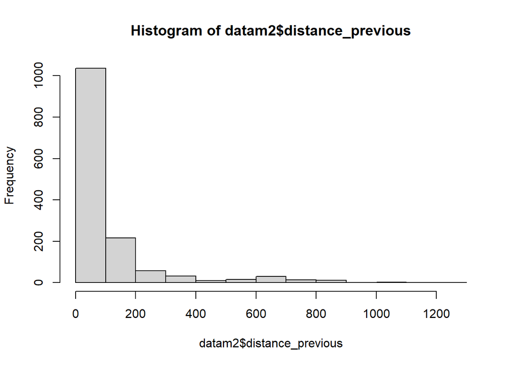

```r
# distribution of movement data
hist(datam2$distance_previous)
```

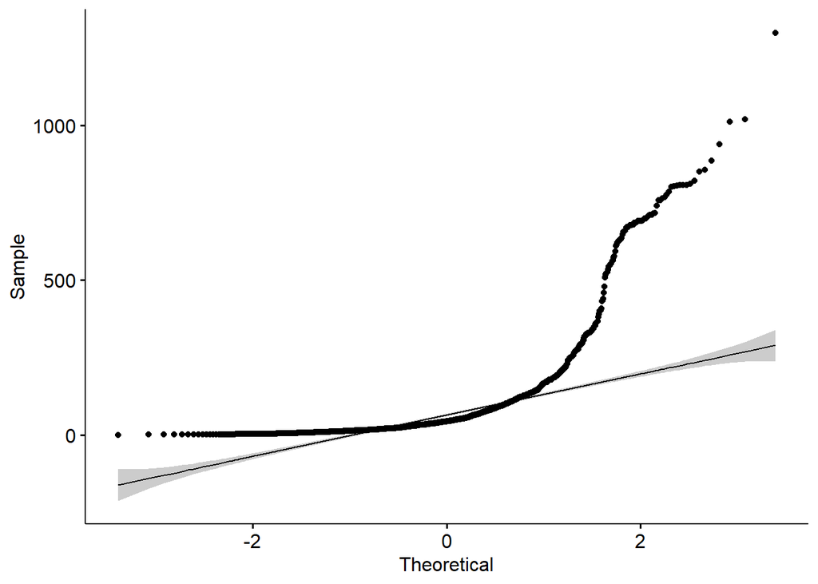

```r
ggqqplot(datam2$distance_previous)
```

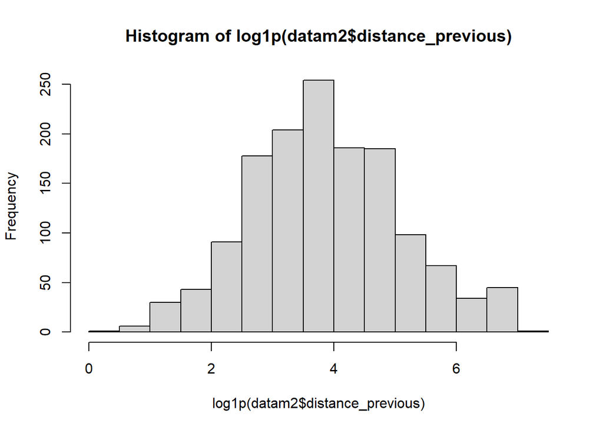

```r
# correct left skew
hist(log1p(datam2$distance_previous))
```

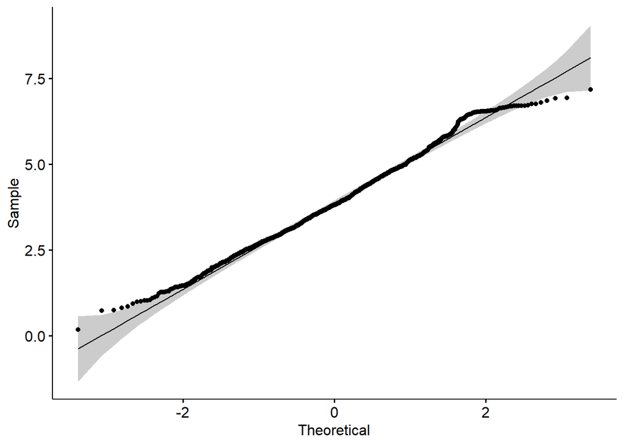

```r
ggqqplot(log1p(datam2$distance_previous))
```

```r
# test difference between the groups with interaction of time as a quadratic
m2 <- glmmTMB(log1p(distance_previous) ~ social * (scale(elapsed) + scale(elapsed2))+ (1|id),
              data = datam2,
              na.action = "na.fail")

# model selection
dm2 <- dredge(m2)

# print best model on AICc
best2 <- get.models(dm2, delta==0)[[1]]
summary(best2)
```

```
##  Family: gaussian  ( identity )
## Formula:
## log1p(distance_previous) ~ scale(elapsed) + scale(elapsed2) +
##     social + (1 | id)
## Data: datam2
##
##      AIC      BIC   logLik deviance df.resid
##   4571.6   4608.4  -2278.8   4557.6     1416
##
## Random effects:
##
## Conditional model:
##  Groups   Name        Variance Std.Dev.
##  id       (Intercept) 0.009636 0.09817
##  Residual             1.432147 1.19672
## Number of obs: 1423, groups:  id, 28
##
## Dispersion estimate for gaussian family (sigma^2): 1.43
##
## Conditional model:
##                              Estimate Std. Error z value Pr(>|z|)
## (Intercept)                   3.65882    0.07068   51.77  < 2e-16 ***
## scale(elapsed)                0.45460    0.12884    3.53 0.000418 ***
## scale(elapsed2)              -0.58060    0.12885   -4.51 6.60e-06 ***
## socialReinforcer - mixed      0.13410    0.09187    1.46 0.144374
## socialReinforcer - exclusive  0.49560    0.09524    5.20 1.96e-07 ***
## ---
## Signif. codes:  0 '***' 0.001 '**' 0.01 '*' 0.05 '.' 0.1 ' ' 1
```

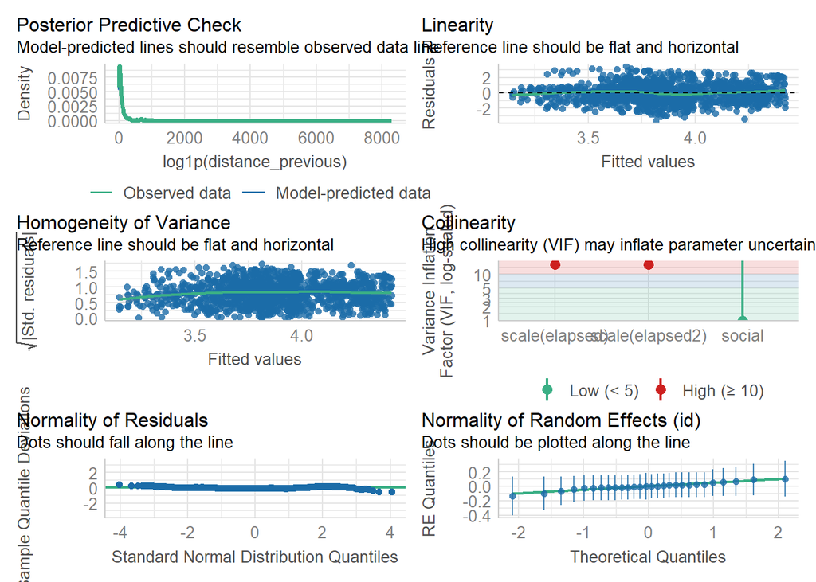

```r
# check model
check_model(best2)
```

```r
# post-hoc comparison of means
emmeans(best2, pairwise ~ social, type = "response")
```

```
## $emmeans
##  social                 response   SE   df lower.CL upper.CL
##  Resident                   37.8 2.74 1416     32.8     43.6
##  Reinforcer - mixed         43.4 2.60 1416     38.6     48.8
##  Reinforcer - exclusive     62.7 4.07 1416     55.2     71.2
##
## Confidence level used: 0.95
## Intervals are back-transformed from the log1p scale
##
## $contrasts
##  contrast                                        estimate     SE   df t.ratio
##  Resident - (Reinforcer - mixed)                   -0.134 0.0919 1416  -1.460
##  Resident - (Reinforcer - exclusive)               -0.496 0.0952 1416  -5.204
##  (Reinforcer - mixed) - (Reinforcer - exclusive)   -0.361 0.0867 1416  -4.169
##  p.value
##   0.3108
##   <.0001
##   0.0001
##
## Note: contrasts are still on the log1p scale. Consider using
##       regrid() if you want contrasts of back-transformed estimates.
## P value adjustment: tukey method for comparing a family of 3 estimates
```

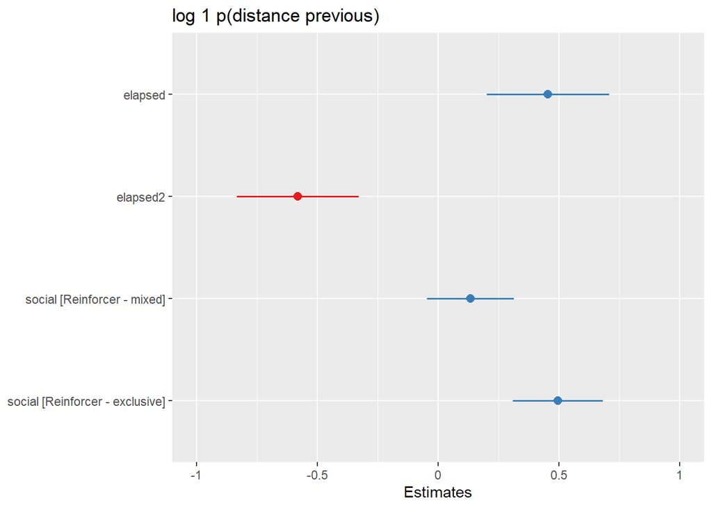

```r
# plot effects
plot_model(best2)
```

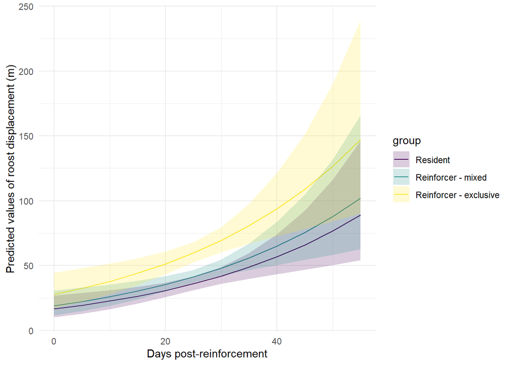

```r
# marginal effects
pred2 <- predict_response(best2, terms = c("elapsed", "social"))

# plot predictions
ggplot(pred2, aes(x, predicted, fill = group, ymin = conf.low, ymax = conf.high)) +
  geom_line(aes(colour = group))+
  geom_ribbon(alpha = 0.2)+
  xlab("Days post-reinforcement") +
  ylab("Predicted values of roost displacement (m)") +
  theme_minimal()+
  scale_fill_viridis_d()+
  scale_colour_viridis_d()
```

**Results:** The best fitting model included social group, time (linear and quadratic), and individual as a random effect. No interactive terms.

Elapsed time had a significant positive linear effect (estimate = 0.455, SE = 0.129, p = 0.00042) and a significant negative quadratic effect (estimate = –0.581, SE = 0.129, p < 0.0001), indicating that distance initially increases with time before reaching a peak and then declines.

Exclusive reinforcers traveled significantly greater distances between consecutive roosts than both mixed reinforcers (p = 0.0001) and residents (p < 0.0001). The mixed reinforcers were not significantly different from residents.

**Interpretation:** Distance between consecutive roosts is a metric for home range establishment in space. Shorter distances between consecutive roosts indicate an individual is staying within a patch and building up familiarity in the roost locations; whereas large distances between consecutive roosts indicate continued searching or lack of stability.

Group co-membership with residents improved roost establishment and fidelity. This could be due to signalling good habitat, thereby reducing the need to explore additional roost sites, or due to social bonds.

### m3: Release site fidelity

Does release site fidelity differ between the social groups?

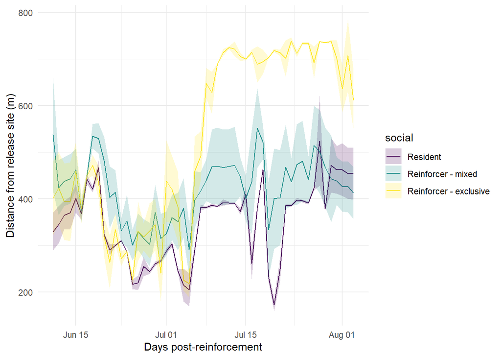

```r
# read in data and filter to reinforcement period
datam3 <- read.csv("results/daily_roost_distance_from_release.csv") %>%
  # add metadata
  left_join(dplyr::select(metadata, c("id", "cohort"))) %>%
  # format dates as dates
  mutate(date = as_date(date)) %>%
  # limit to reinforcement period
  filter(date %in% rein_dates) %>%
  # add a time elapsed post-release variable
  mutate(elapsed = as.numeric(date - as_date("2023-06-10"))) %>%
  # add column for membership to social group
  mutate(social = ifelse(id %in% club, "Reinforcer - exclusive", ifelse(cohort == "Resident", "Resident", "Reinforcer - mixed"))) %>%
  # convert group to factor and set resident as the intercept
  mutate(social = factor(social, levels = c("Resident", "Reinforcer - mixed", "Reinforcer - exclusive"))) %>%
  # add quadratic term for time
  mutate(elapsed2 = elapsed^2)

# create social group means
sum3 <- datam3 %>%
  group_by(date, social) %>%
  summarise(dist = mean(dist_release),
            upper = dist + std.error(dist_release),
            lower = dist - std.error(dist_release)) %>%
  arrange(date)

# plot distance from release site over time as social group means
ggplot(sum3, aes(date, dist, ymin = lower, ymax = upper)) +
  geom_path(aes(colour = social)) +
  geom_ribbon(aes(fill = social), alpha = 0.2) +
  xlab("Days post-reinforcement") +
  ylab("Distance from release site (m)") +
  theme_minimal() +
  scale_fill_viridis_d()+
  scale_colour_viridis_d()
```

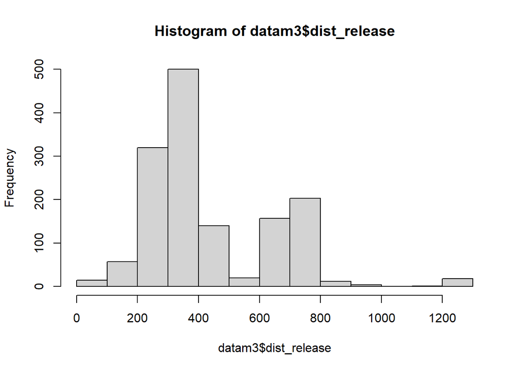

```r
# distribution of movement data
hist(datam3$dist_release)
```

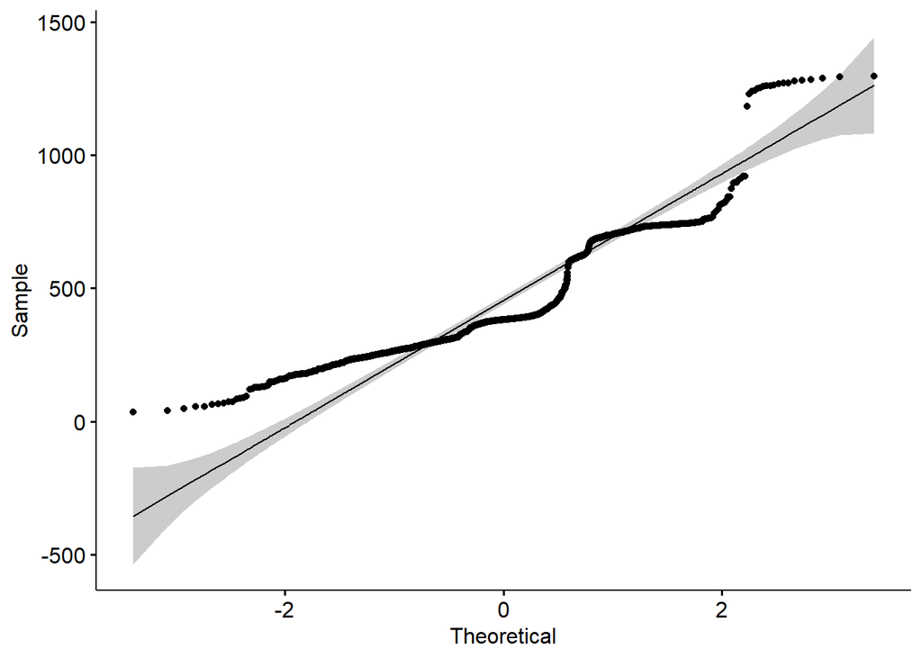

```r
ggqqplot(datam3$dist_release)
```

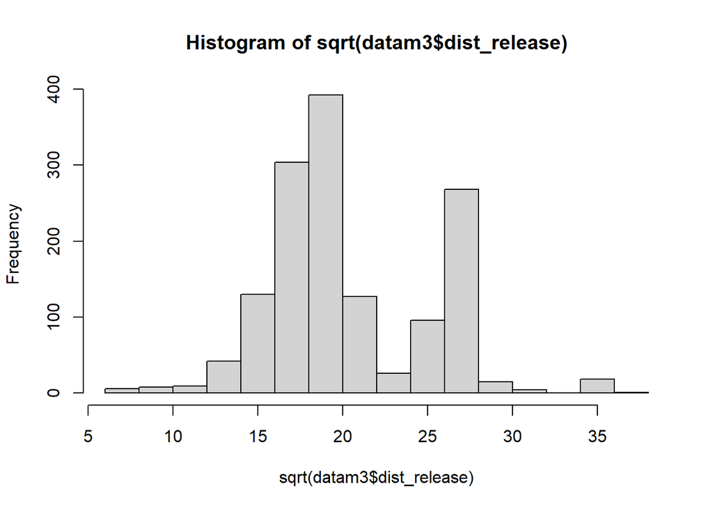

```r
# correct left skew - still not great but a bit better
hist(sqrt(datam3$dist_release))
```

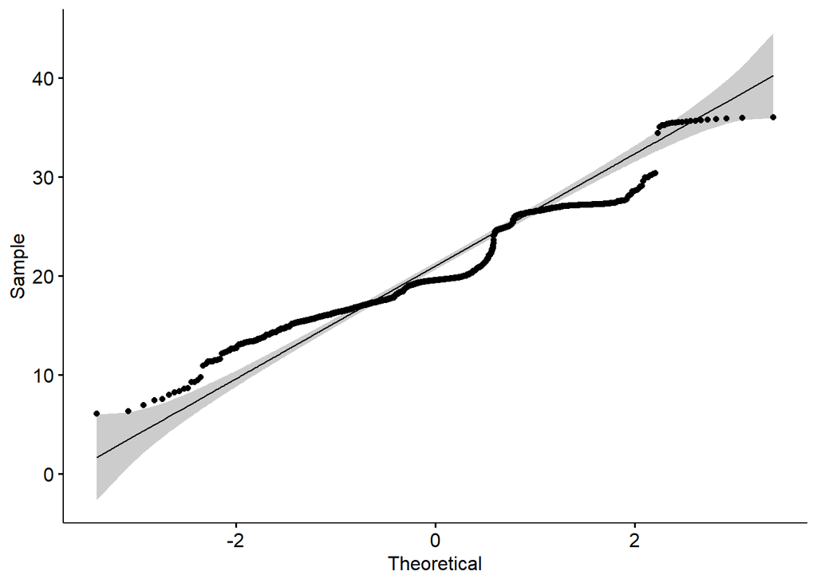

```r
ggqqplot(sqrt(datam3$dist_release))
```

```r
# test difference between the groups with interaction of time as a quadratic
m3 <- glmmTMB(sqrt(dist_release) ~ social * (scale(elapsed) + scale(elapsed2))+ (1|id),
              data = datam3,
              na.action = "na.fail")

# model selection
dm3 <- dredge(m3)

# print best model on AICc
best3 <- get.models(dm3, delta==0)[[1]]
summary(best3)
```

```
##  Family: gaussian  ( identity )
## Formula:
## sqrt(dist_release) ~ scale(elapsed) + scale(elapsed2) + social +
##     (1 | id) + scale(elapsed):social + scale(elapsed2):social
## Data: datam3
##
##      AIC      BIC   logLik deviance df.resid
##   7687.1   7745.2  -3832.6   7665.1     1435
##
## Random effects:
##
## Conditional model:
##  Groups   Name        Variance Std.Dev.
##  id       (Intercept)  3.862   1.965
##  Residual             11.093   3.331
## Number of obs: 1446, groups:  id, 28
##
## Dispersion estimate for gaussian family (sigma^2): 11.1
##
## Conditional model:
##                                              Estimate Std. Error z value
## (Intercept)                                   18.4351     0.7180  25.677
## scale(elapsed)                                -3.5578     0.6840  -5.201
## scale(elapsed2)                                4.3929     0.6843   6.419
## socialReinforcer - mixed                       1.6158     0.9414   1.716
## socialReinforcer - exclusive                   3.9008     0.9836   3.966
## scale(elapsed):socialReinforcer - mixed        1.6756     0.8922   1.878
## scale(elapsed):socialReinforcer - exclusive    5.7875     0.9249   6.258
## scale(elapsed2):socialReinforcer - mixed      -2.1305     0.8931  -2.386
## scale(elapsed2):socialReinforcer - exclusive  -3.2476     0.9225  -3.520
##                                              Pr(>|z|)
## (Intercept)                                   < 2e-16 ***
## scale(elapsed)                               1.98e-07 ***
## scale(elapsed2)                              1.37e-10 ***
## socialReinforcer - mixed                     0.086103 .
## socialReinforcer - exclusive                 7.32e-05 ***
## scale(elapsed):socialReinforcer - mixed      0.060370 .
## scale(elapsed):socialReinforcer - exclusive  3.91e-10 ***
## scale(elapsed2):socialReinforcer - mixed     0.017054 *
## scale(elapsed2):socialReinforcer - exclusive 0.000431 ***
## ---
## Signif. codes:  0 '***' 0.001 '**' 0.01 '*' 0.05 '.' 0.1 ' ' 1
```

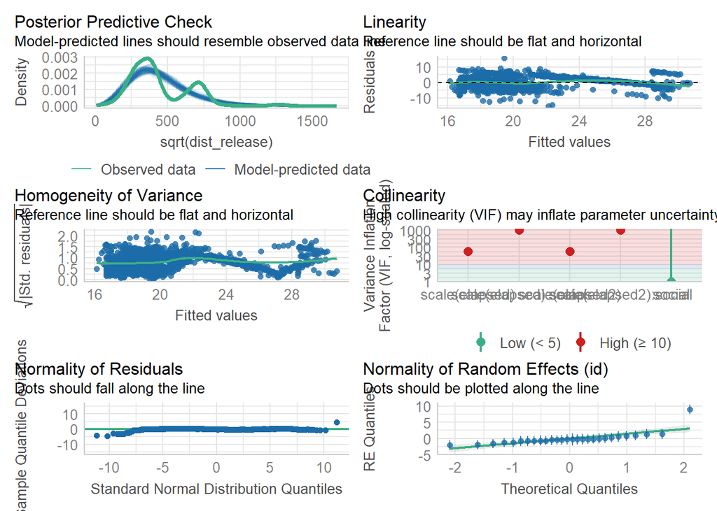

```r
# check model
check_model(best3)
```

```r
# post-hoc comparison of means
emmeans(best3, pairwise ~ social, type = "response")
```

```
## $emmeans
##  social                 response   SE   df lower.CL upper.CL
##  Resident                    340 26.5 1435      290      394
##  Reinforcer - mixed          402 24.4 1435      356      451
##  Reinforcer - exclusive      499 30.0 1435      442      560
##
## Confidence level used: 0.95
## Intervals are back-transformed from the sqrt scale
##
## $contrasts
##  contrast                                        estimate    SE   df t.ratio
##  Resident - (Reinforcer - mixed)                    -1.62 0.941 1435  -1.716
##  Resident - (Reinforcer - exclusive)                -3.90 0.984 1435  -3.966
##  (Reinforcer - mixed) - (Reinforcer - exclusive)    -2.28 0.907 1435  -2.519
##  p.value
##   0.1994
##   0.0002
##   0.0318
##
## Note: contrasts are still on the sqrt scale. Consider using
##       regrid() if you want contrasts of back-transformed estimates.
## P value adjustment: tukey method for comparing a family of 3 estimates
```

```r
# post-hoc comparison of slopes
emtrends(best3, pairwise ~ social, var = "elapsed")
```

```
## $emtrends
##  social                 elapsed.trend     SE   df lower.CL upper.CL
##  Resident                      -0.229 0.0439 1435  -0.3148  -0.1424
##  Reinforcer - mixed            -0.121 0.0368 1435  -0.1931  -0.0487
##  Reinforcer - exclusive         0.143 0.0400 1435   0.0648   0.2217
##
## Confidence level used: 0.95
##
## $contrasts
##  contrast                                        estimate     SE   df t.ratio
##  Resident - (Reinforcer - mixed)                   -0.108 0.0573 1435  -1.878
##  Resident - (Reinforcer - exclusive)               -0.372 0.0594 1435  -6.258
##  (Reinforcer - mixed) - (Reinforcer - exclusive)   -0.264 0.0543 1435  -4.861
##  p.value
##   0.1454
##   <.0001
##   <.0001
##
## P value adjustment: tukey method for comparing a family of 3 estimates
```

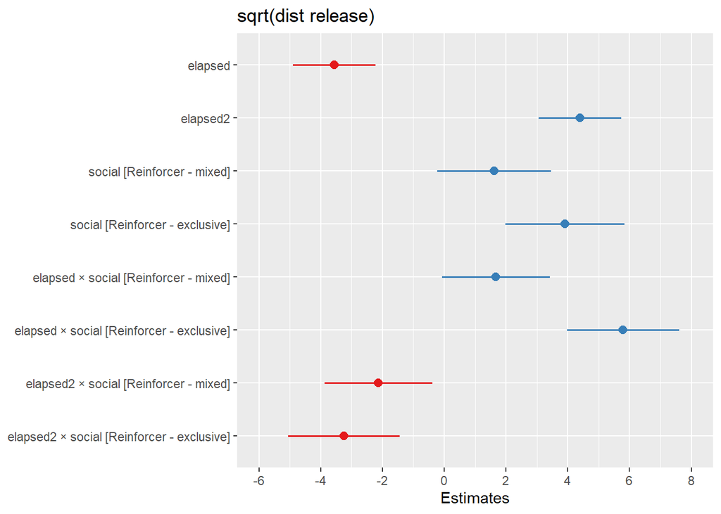

```r
# plot effects
plot_model(best3)
```

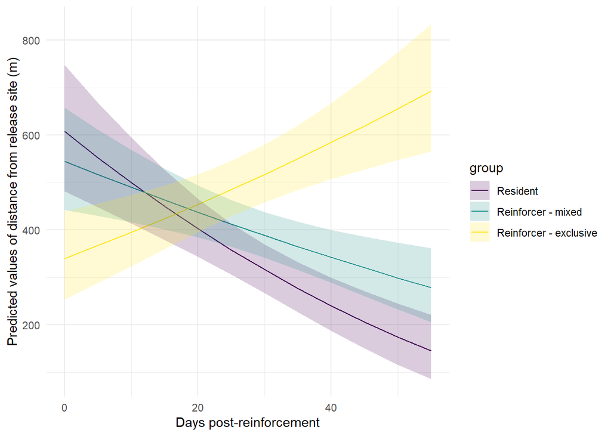

```r
# marginal effects
pred3 <- predict_response(best3, terms = c("elapsed", "social"))

# plot predictions
ggplot(pred3, aes(x, predicted, fill = group, ymin = conf.low, ymax = conf.high)) +
  geom_line(aes(colour = group))+
  geom_ribbon(alpha = 0.2)+
  xlab("Days post-reinforcement") +
  ylab("Predicted values of distance from release site (m)") +
  theme_minimal()+
  scale_fill_viridis_d()+
  scale_colour_viridis_d()
```

**Results:** The best fitting model included social group and time (linear and quadratic), the interaction between these, and individual as a random effect.

Exclusive reinforcers moved significantly further from the release site than both mixed reinforcers (p = 0.031) and residents (p = 0.0002). Additionally, the rate of change was significantly different for exclusive reinforcers - who continued to move away from the release site- compared to the other groups that declined over time (p < 0.0001).

**Interpretation:** Mixed reinforcers had greater release site fidelity than exclusive reinforcers. Tactically, site fidelity is importancde because, first, hyperdispersal increases chance of predation, and second, the release area has suitable resources for long-term survival and recruitment.

An alternative explanation is that the exclusive birds were pushed away e.g. due to territoriality or population capacity- but I don’t think this is the case because they continued to have interactions with the other group including some time roosting in the central woodland.

#### Release site fidelity map

How do they move away from the release site over time

[figure not shown]

```r
# Google API key for ggmaps
ggmap::register_google(key = readChar("apikey_google.txt", nchars = file.info("apikey_google.txt")$size))

# Background map MR zones 1 and 2
map_z14 <- get_map(c(144.4380, -37.9000), zoom=14, maptype = "satellite")
map_z15 <- get_map(c(144.4380, -37.9000), zoom=15, maptype = "satellite")

# Define fence polygons (zones 1 and 2)
mtr <- rbind(
  ## zone 1
  c(-37.897319, 144.429048), # S end of NW diagonal
  c(-37.894066, 144.432334), # N end of NW diagonal, i.e. NW corner
  c(-37.894749, 144.438305), # bend at main gate
  c(-37.894693, 144.438324), # main gate
  c(-37.894803, 144.439214), # bend before N Z1/2 gate
  c(-37.894718, 144.439337), # N Z1/2 gate, i.e. NE corner
  ## zone 2
  c(-37.892433, 144.440236), # N boundary internal aviary/Z2 i.e. NW corner
  c(-37.892803, 144.443374), # Z2 northern boundary bend 1
  c(-37.893634, 144.444076), # Z2 northern boundary bend 2
  c(-37.894585, 144.447739), # N end of Z2/Z3 boundary, i.e. NE corner
  c(-37.896515, 144.446789), # Z2/Z3 boundary bend 1
  c(-37.896726, 144.446099), # Z2/Z3 boundary bend 2
  c(-37.897964, 144.445706), # Z2/Z3 boundary bend 3
  c(-37.899960, 144.444517), # S end of Z2/Z3 boundary, i.e. SE corner
  c(-37.899908, 144.444288), # Z2/btrw NE corner
  c(-37.898280, 144.440662), # Z1/btrw pen NW corner
  ## zone 1
  c(-37.900692, 144.440368), # Z1/btrw SW corner
  c(-37.902610, 144.443002), # Z1/btrw SE corner
  c(-37.909538, 144.439648), # Z1 SE corner
  c(-37.908999, 144.434965), # Z1 southern boundary bend 1
  c(-37.907537, 144.433359), # Z1 southern boundary bend 2
  c(-37.905958, 144.430140), # Z1 southern boundary bend 3
  c(-37.905486, 144.429479), # Z1 southern boundary bend 4
  c(-37.904649, 144.427566), # Z1 SW corner
  c(-37.897319, 144.429048)  # S end of NW diagonal
  ) %>%  vect(type = "polygons", crs = "EPSG:4326") %>%
  # transpose
  t() %>%
  # add a buffer for GPS accuracy of 30m for analysis, and 10m for mapping
  buffer(10)

ggmap(map_z15)+
  # plot roosts colour by time
  geom_point(aes(longitude, latitude, colour = date),
             size = 2, data = datam2, inherit.aes = FALSE)+
  # add release location
  geom_point(aes(144.434323, -37.902374),
             colour = "white", size = 5, shape = 13, inherit.aes = FALSE)+
  # add fence
  geom_spatvector(data = mtr, inherit.aes = FALSE, fill = NA, colour = "white",
                  linetype = "longdash")+
  # wrap by period
  facet_wrap(~social)+
  # theme options
  scale_colour_viridis_c(trans = "date", name = "2023")+
  theme_void()+
  scale_y_continuous(expand = expansion(mult = c(0, 0.01)))+
  theme(legend.position="bottom",
        legend.key.width = unit(3, 'cm'),
        strip.text = element_text(size = 13))+
  # add north in just the resident facet panel
  annotation_north_arrow(data  = subset(datam2, social == "Resident"),
                         location = "tr",
                         height = unit(0.8, "cm"), width = unit(0.7, "cm"),
                         style = north_arrow_orienteering(text_col = "black"))+
  # add scale bar in just the resident facet panel
  annotation_scale(data  = subset(datam2, social == "Resident"),
                   location = "br", text_col = "black",
                   pad_x = unit(0.1, "cm"), pad_y = unit(0.4, "cm"))
```

### m4: Home range establishment

Does home range size differ between the social groups?

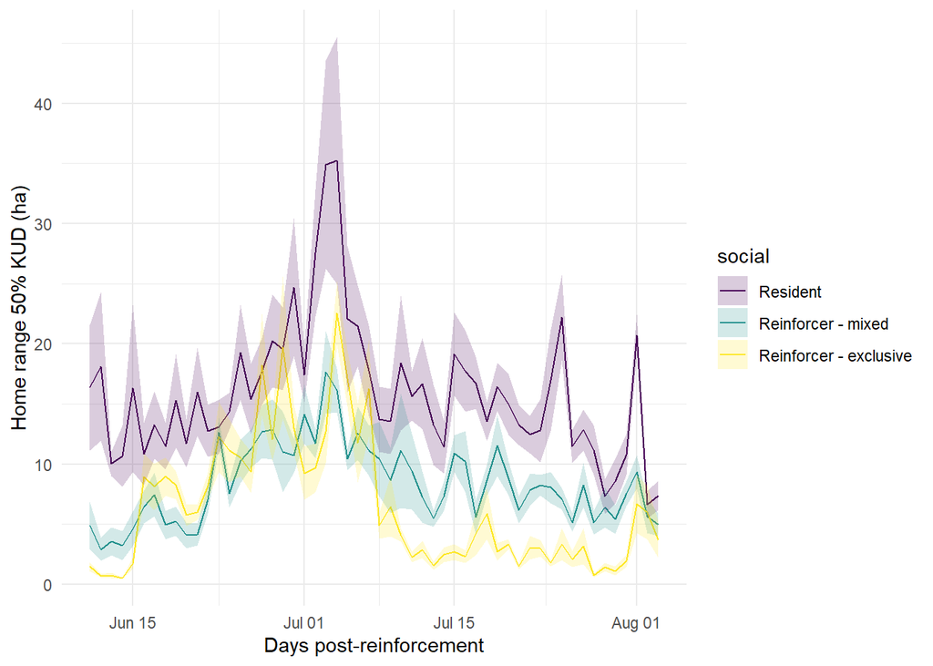

```r
# read in data and filter to reinforcement period
datam4 <- read.csv("results/daily_hr_area.csv") %>%
  # add metadata
  left_join(dplyr::select(metadata, c("id", "cohort"))) %>%
  # format dates as dates
  mutate(date = as_date(date)) %>%
  # limit to reinforcement period
  filter(date %in% rein_dates) %>%
  # add a time elapsed post-release variable
  mutate(elapsed = as.numeric(date - as_date("2023-06-10"))) %>%
  # add column for membership to social group
  mutate(social = ifelse(id %in% club, "Reinforcer - exclusive", ifelse(cohort == "Resident", "Resident", "Reinforcer - mixed"))) %>%
  # convert group to factor and set resident as the intercept
  mutate(social = factor(social, levels = c("Resident", "Reinforcer - mixed", "Reinforcer - exclusive"))) %>%
  # add quadratic term for time
  mutate(elapsed2 = elapsed^2)

# create social group means
sum4 <- datam4 %>%
  group_by(date, social) %>%
  summarise(dist = mean(area),
            upper = dist + std.error(area),
            lower = dist - std.error(area)) %>%
  arrange(date)

# plot distance from release site over time as social group means
ggplot(sum4, aes(date, dist, ymin = lower, ymax = upper)) +
  geom_path(aes(colour = social)) +
  geom_ribbon(aes(fill = social), alpha = 0.2) +
  xlab("Days post-reinforcement") +
  ylab("Home range 50% KUD (ha)") +
  theme_minimal() +
  scale_fill_viridis_d()+
  scale_colour_viridis_d()
```

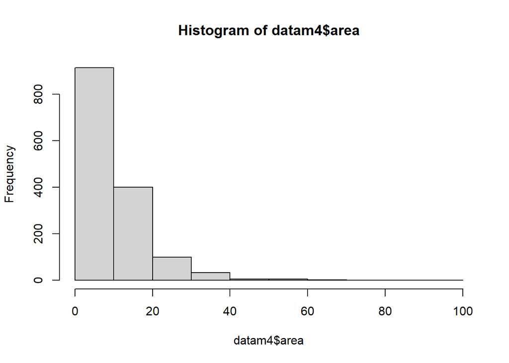

```r
# distribution of movement data
hist(datam4$area)
```

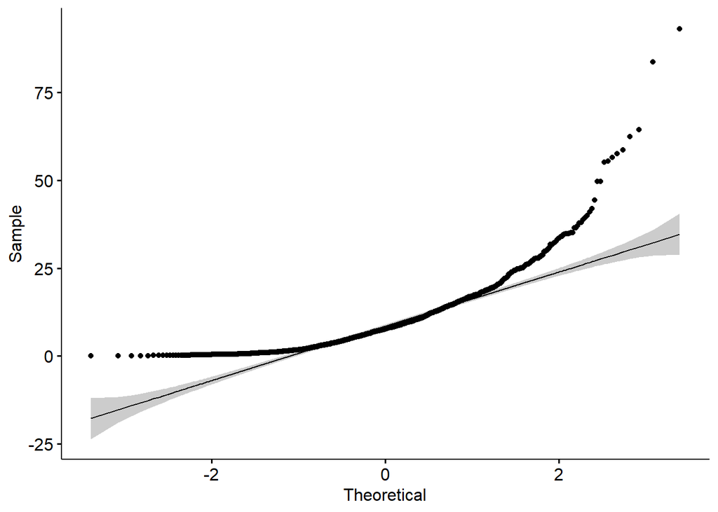

```r
ggqqplot(datam4$area)
```

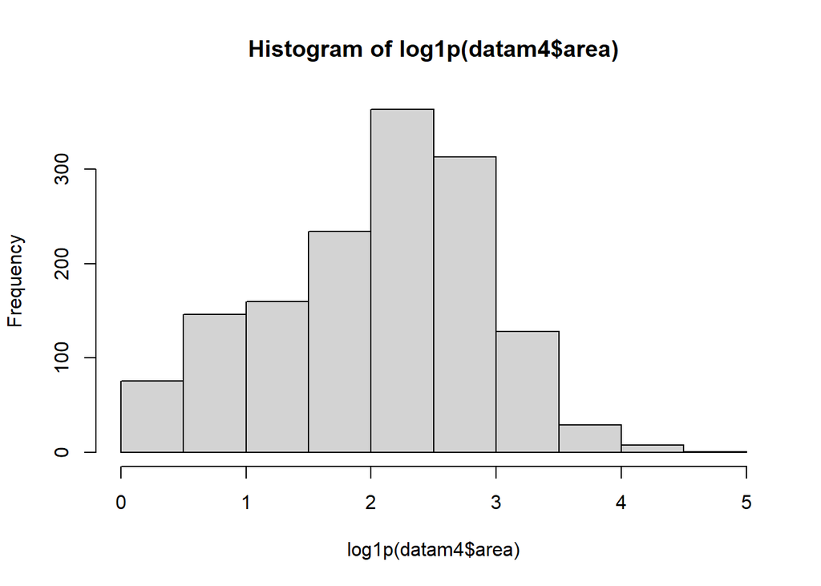

```r
# correct left skew
hist(log1p(datam4$area))
```

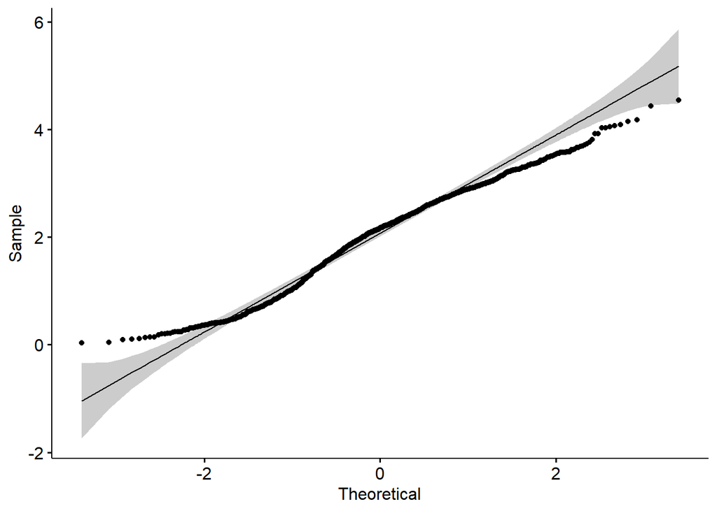

```r
ggqqplot(log1p(datam4$area))
```

```r
# test difference between the groups with interaction of time as a quadratic
m4 <- glmmTMB(log1p(area) ~ social * (scale(elapsed) + scale(elapsed2))+ (1|id),
              data = datam4,
              na.action = "na.fail")

# model selection
dm4 <- dredge(m4)

# print best model on AICc
best4 <- get.models(dm4, delta==0)[[1]]
summary(best4)
```

```
##  Family: gaussian  ( identity )
## Formula:
## log1p(area) ~ scale(elapsed) + scale(elapsed2) + social + (1 |
##     id) + scale(elapsed):social + scale(elapsed2):social
## Data: datam4
##
##      AIC      BIC   logLik deviance df.resid
##   2942.6   3000.7  -1460.3   2920.6     1447
##
## Random effects:
##
## Conditional model:
##  Groups   Name        Variance Std.Dev.
##  id       (Intercept) 0.03953  0.1988
##  Residual             0.41953  0.6477
## Number of obs: 1458, groups:  id, 28
##
## Dispersion estimate for gaussian family (sigma^2): 0.42
##
## Conditional model:
##                                              Estimate Std. Error z value
## (Intercept)                                   2.65656    0.07827   33.94
## scale(elapsed)                                0.67268    0.13262    5.07
## scale(elapsed2)                              -0.74923    0.13257   -5.65
## socialReinforcer - mixed                     -0.65687    0.10225   -6.42
## socialReinforcer - exclusive                 -1.04280    0.10669   -9.77
## scale(elapsed):socialReinforcer - mixed       0.47658    0.17182    2.77
## scale(elapsed):socialReinforcer - exclusive   0.41700    0.17861    2.33
## scale(elapsed2):socialReinforcer - mixed     -0.34470    0.17196   -2.00
## scale(elapsed2):socialReinforcer - exclusive -0.61712    0.17816   -3.46
##                                              Pr(>|z|)
## (Intercept)                                   < 2e-16 ***
## scale(elapsed)                               3.93e-07 ***
## scale(elapsed2)                              1.59e-08 ***
## socialReinforcer - mixed                     1.33e-10 ***
## socialReinforcer - exclusive                  < 2e-16 ***
## scale(elapsed):socialReinforcer - mixed      0.005542 **
## scale(elapsed):socialReinforcer - exclusive  0.019557 *
## scale(elapsed2):socialReinforcer - mixed     0.045020 *
## scale(elapsed2):socialReinforcer - exclusive 0.000532 ***
## ---
## Signif. codes:  0 '***' 0.001 '**' 0.01 '*' 0.05 '.' 0.1 ' ' 1
```

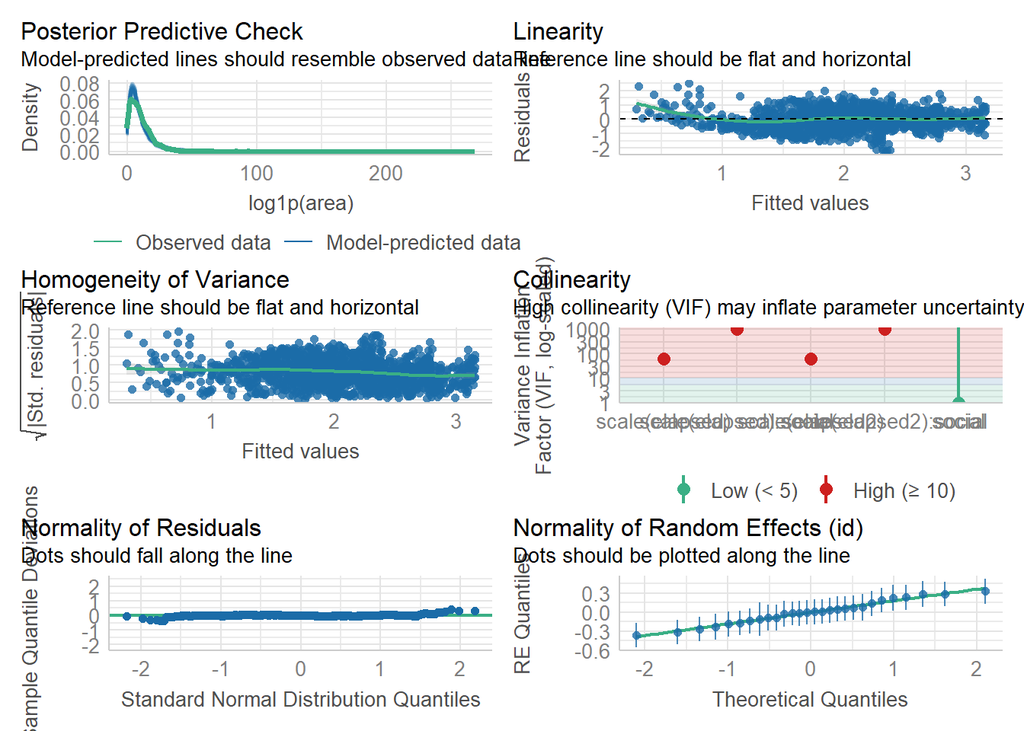

```r
# check model
check_model(best4)
```